# Comparison of Oyster Reef Densities: EQIP vs. FHE vs. Natural

For this comparison, we will use a combination of oyster sampling through the EQIP and FHE monitoring projects.

The 3 treatments are:

EQIP (est. 2008 - 2010)

FHE (est. Fall 2015)

Natural

The natural reefs are located in Foster Cove, while the FHE and EQIP reefs are located in the Northern and Southern portions of the Spawner Sanctuary within Ninigret Pond.

The purpose of this comparison is to investigate whether restoration reefs of different ages mimic naturally occuring reefs in the same water body.

| Treatment | Replicates |
| --- | --- |
| EQIP | 40 |
| FHE | 4 |
| Natural | 5 |

We have varying replication by treatment, and 4-5 replicates is pretty low.

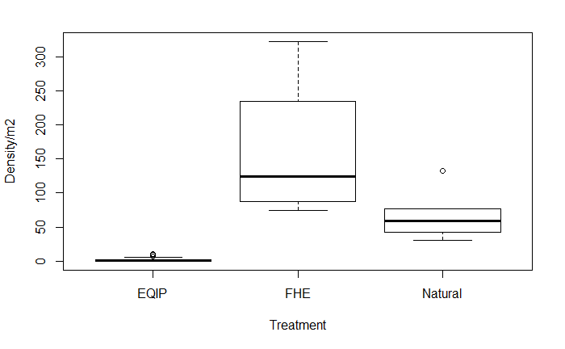

|  | ID | Density | Treatment |
| --- | --- | --- | --- |
| 46 | Nin-1S | 322.66667 | FHE |
| 47 | Nin-2S | 74.66667 | FHE |
| 48 | Nin-3S | 147.33333 | FHE |
| 49 | Nin-4S | 100.50000 | FHE |

Natural Reefs contain what appears to be an outlier, but we will keep in sample.

We also notice “Nin-1S” reef in the FHE treatment has an outlier, but due to low replication we will include in sample. This error is likely due to the aggressive subsampling coupled with large variation in oyster density across reefs. We will increase the number of quadrats sampled per reef in future oyster monitoring.

EQIP reefs contain a large proportion of 0 density reefs.

```r
library(car)
model_dat <- aov(Density ~ Treatment, data = dat)
leveneTest(model_dat)
```

```
Levene's Test for Homogeneity of Variance (center = median)
      Df F value    Pr(>F)
group  2  19.108 9.108e-07 ***
      46
---
Signif. codes:  0 ‘***’ 0.001 ‘**’ 0.01 ‘*’ 0.05 ‘.’ 0.1 ‘ ’ 1
```

```r
shapiro.test(model_dat$residuals)
```

```
    Shapiro-Wilk normality test

data:  model_dat$residuals
W = 0.51545, p-value = 1.733e-11
```

Data are non-normal and heteroscedastic

Attempt log + 1 transformation

```r
dat$logdens <- log(dat$Density + 1)
log_model_dat <- aov(logdens~Treatment,dat)
leveneTest(log_model_dat)
```

```
Levene's Test for Homogeneity of Variance (center = median)
      Df F value Pr(>F)
group  2  0.5981 0.5541
      46
```

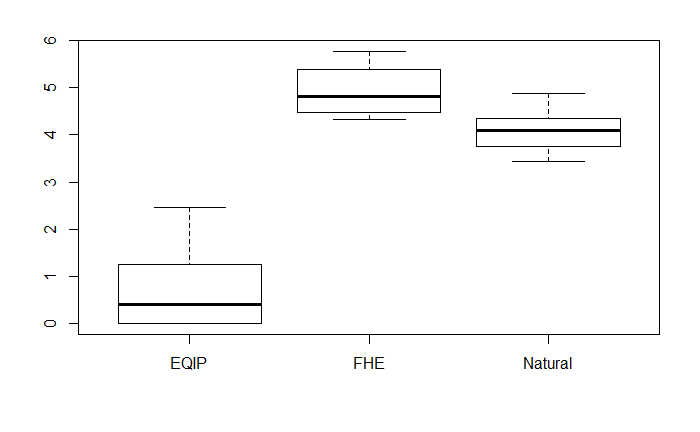

```r
boxplot(dat$logdens~dat$Treatment)
```

```r
shapiro.test(log_model_dat$residuals)
```

```
    Shapiro-Wilk normality test

data:  log_model_dat$residuals
W = 0.87146, p-value = 7.271e-05
```

Log +1 transformed data are homoscedastic but still non-normal distribtution.

Will proceed with Kruskal-Wallis Test.

```r
kruskal.test(logdens~Treatment, dat)
```

```
    Kruskal-Wallis rank sum test

data:  logdens by Treatment
Kruskal-Wallis chi-squared = 22.279, df = 2, p-value = 1.453e-05
```

We find that there is a significant difference in rank between treatments

Post-hoc pairwise comparisons:

```r
posthoc.kruskal.nemenyi.test(logdens~Treatment, dat)
```

```
    Pairwise comparisons using Tukey and Kramer (Nemenyi) test
                   with Tukey-Dist approximation for independent samples

data:  logdens by Treatment

        EQIP   FHE
FHE     0.0013 -
Natural 0.0019 0.9422

P value adjustment method: none
```

We determine that EQIP is significant from FHE & Natural

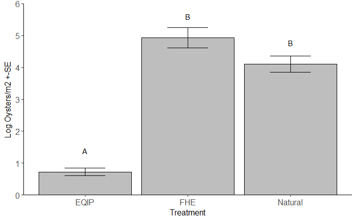

```r
library(sciplot)
library(ggplot2)
log_plot_data_mean <- aggregate(dat$logdens~dat$Treatment, FUN = mean)
colnames(log_plot_data_mean) <- c("Treatment","Log.Mean")
log_plot_data_se <- aggregate(dat$logdens~dat$Treatment, FUN = se)
colnames(log_plot_data_se) <- c("Treatment", "Log.SE")
log_plot_data <- merge(log_plot_data_mean,log_plot_data_se, by = "Treatment")
log_plot_data$Label[1] <- "A"
log_plot_data$Label[2:3] <- "B"
log_plot <- ggplot(log_plot_data, aes(x=Treatment, y=Log.Mean)) +
  geom_bar(position=position_dodge(), stat="identity",colour = "black", fill = "grey") +
  geom_errorbar(aes(ymin=Log.Mean-Log.SE, ymax=Log.Mean+Log.SE),
                width=.4,                    # Width of the error bars
                position=position_dodge(.9)) +
  geom_text(data=log_plot_data, aes(x = Treatment, y = Log.Mean, label = Label),vjust = -3) +
  ylab("Log Oysters/m2 +-SE") +
  xlab("Treatment") +
  theme(axis.text = element_text(size = 12),legend.title=element_text(size=12),
        axis.title = element_text(size = 12),
        legend.text = element_text(size = 12),
        panel.grid.major = element_blank(),
        panel.grid.minor = element_blank(),
        panel.background = element_blank(),
        axis.line = element_line(colour = ("black"))) +
        scale_y_continuous(expand = c(0, 0),limits = c(0,6))
log_plot
```

[output not shown]